# PARTII (FEBRUARY 2019 FORDGOBIKE DATA EXPLORATION)

## by (EKPOT GODSWILL TOM)

## Investigation Overview

We perform this analysis to uncover the prevalence of the bike sharing system and factors that may affect it.

## Dataset Overview

This data set includes information about individual rides made in a bike-sharing system covering the greater San Francisco Bay area.

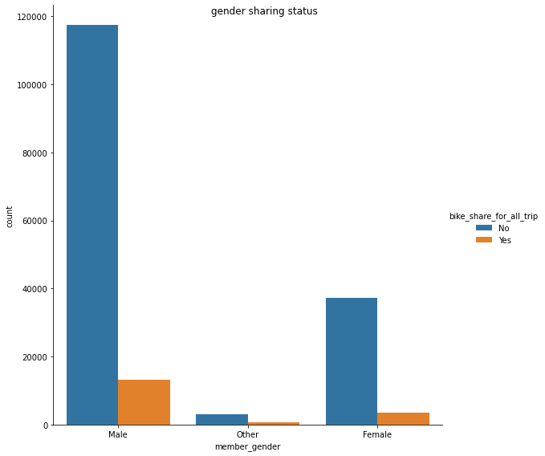

## Bike sharing options for users

#### This chart however shows clearly that customers do not use the bike sharing option at all and a percentaage of the subscribers use the sharing option.

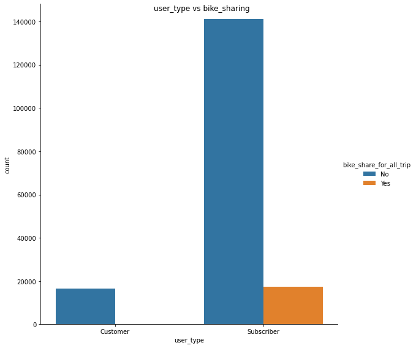

## Bike traffic time chart

#### This chart accurately shows the time of the day with the highest customer usage. From the chart, we can observe that 7-9am and 4-6pm see the most traffic of riders

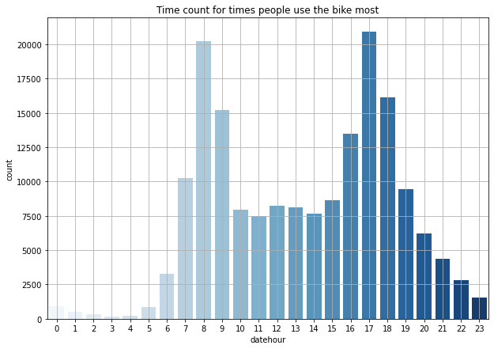

## User type duration

#### We pbserve here that customers ride for longer periods than subscribers

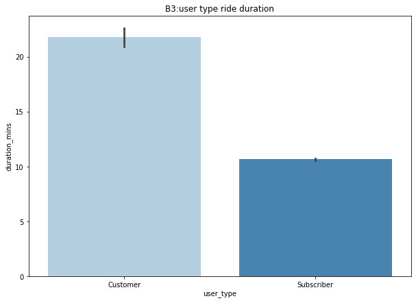

# Facet grid

### This is a multivariate chart to demonstrate how member gender relates to user type and how they are affected by member age and duration.

#### There are more male riders than female riders

#### The duration reducs with age therefore, the older the rider is, the less time he/she is going to ride for

#### There is little or no difference between theh the distribution of customers and subscribers

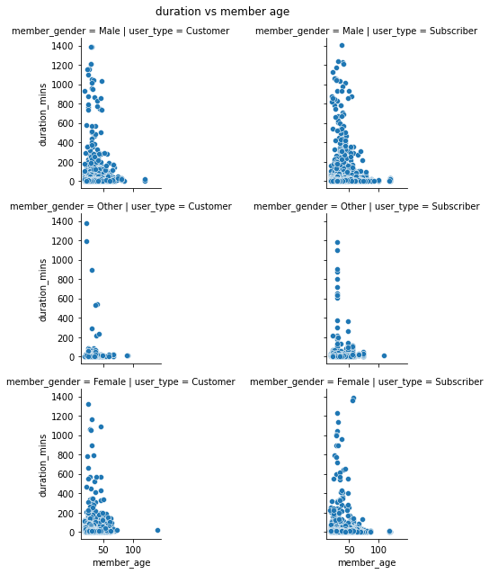